# Raport — modele opłacalności lokalizacji dla portalu Nocarz

Zespół: The Szponters - Temat 12

Jan Szwagierczak  
Łukasz Szydlik

## 1. Kontekst i sformułowanie zadania

Zadanie biznesowe: *"Czasami zastanawiamy się, w którym miejscu powinniśmy poszukać jakiegoś nowego lokalu do dodania, tak aby był jak najbardziej opłacalny."*

Doprecyzowanie (zgodne z Machine Learning Canvas):

- **Typ zadania:** regresja punktowa w przestrzeni + post-processing (ranking, „białe plamy").
- **Predykcja:** szacowany **roczny przychód** lokalu (`annual_revenue`) dla profilu referencyjnego w danej lokalizacji.
- **Beneficjent:** dział Business Development — otrzymuje mapę potencjału i listę Top-N lokalizacji o wysokim potencjale i niskiej saturacji rynku.
- **Klucz:** predykcja musi opierać się wyłącznie na cechach znanych **przed** wystawieniem oferty (lokalizacja, typ lokalu, otoczenie rynkowe) — nie na wynikach po starcie.

## 2. Inżynieria zmiennej celu (Ground Truth)

Etykiety z Canvas (`estimated_revenue_l365d`, `estimated_occupancy_l365d`) oraz `calendar_prev.csv` **nie istnieją** w danych. Cel wyznaczamy z `calendar.csv` (kalendarz na okno ~365 dni, 2024‑12‑06 → 2025‑12‑09):

```
annual_revenue = Σ price       po nocach zarezerwowanych (available == 'f')
occupancy      = noce_zarezerwowane / wszystkie_noce   ∈ [0, 1]
```

Modelujemy **oba wyniki z Canvas**: roczny przychód (główne KPI) i obłożenie (`occupancy`). `calendar.csv` (33 mln wierszy, 1,4 GB) przetwarzamy strumieniowo w porcjach (`build_targets.py`).

**Założenie:** `available == False` traktujemy jako „zarezerwowane" (najlepszy dostępny sygnał realizacji przychodu; w danych syntetycznych akceptowalne — odnotowane jawnie).

Cel jest silnie prawoskośny (mediana 29 200 EUR, ale wartości skrajne do 329 mln EUR — nierealne ceny). W modelowaniu **odcinamy górny 1%** (dane śmieciowe); zera (lokale nigdy nierezerwowane) zostają. Rozkład: `figures/eda_target_distribution.png`.

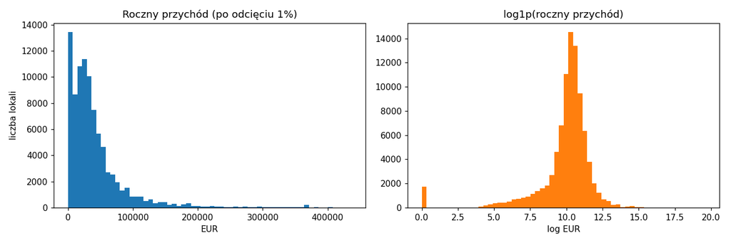

```python
from IPython.display import Image, display
display(Image(filename='figures/eda_target_distribution.png'))
```

## 3. Cechy i unikanie wycieku danych

Zestaw cech (identyczny w treningu i w serwowaniu — `src/nocarz/features.py`):

| Grupa | Cechy |
| --- | --- |
| Geograficzne | `latitude`, `longitude`, `neighbourhood_cleansed` (20 dzielnic), `dist_center_km` (do Point Zéro), `dist_nearest_landmark_km` (do najbliższego z 7 kluczowych punktów) |
| Typologia / standard | `property_type`, `room_type`, `accommodates`, `amenities_count`, `bathrooms` (parsowane z `bathrooms_text`), `premium_amenities_count` (liczba kategorii udogodnień premium) |
| Otoczenie (przestrzenne) | gęstość konkurencji w 250/500/1000 m (`cKDTree`), mediana ceny dzielnicy, `district_price_volatility` (zmienność ceny dzielnicy), średnia ocena lokalizacji dzielnicy |

`bathrooms` i `premium_amenities_count` realizują postulaty Canvas (parsowanie `bathrooms_text`, „obecność cech premium"). W serwisie są **opcjonalne** — przy braku imputujemy medianę miejską (łazienki) i 0 (premium), więc minimalne żądanie nadal zwraca predykcję, zachowując zgodność trening/serwowanie.

`dist_center_km` / `dist_nearest_landmark_km` realizują postulat Canvas „odległość od kluczowych punktów" — są czystą funkcją współrzędnych (parytet trening/serwowanie zagwarantowany). Atrybut historyczny Canvas „zmienność ceny" realizujemy jako **`district_price_volatility`** — współczynnik zmienności ceny w dzielnicy (`std/mean`). Ponieważ `calendar_prev.csv` (szereg czasowy) nie istnieje w danych, jest to proxy przekrojowe na poziomie dzielnicy (znane przed startem oferty).

**Anty‑wyciek:** świadomie **pomijamy** własną cenę, własne oceny i obłożenie lokalu — to wyniki po starcie, niedostępne dla nowej oferty. Gęstość konkurencji liczymy rzutując współrzędne na metry (przybliżenie równoodległościowe) i odpytując `cKDTree` (bez geopandas). Analiza: `figures/eda_revenue_by_district.png` — zmienność **wewnątrz** dzielnic przewyższa zmienność **między** nimi, co z góry ogranicza model „średniej dzielnicy".

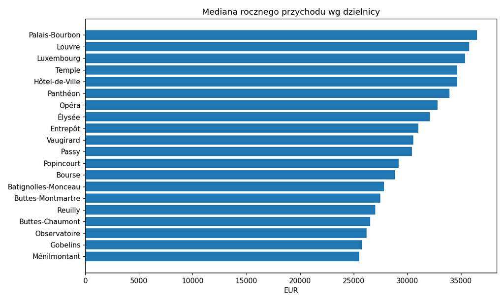

```python
from IPython.display import Image, display
display(Image(filename='figures/eda_revenue_by_district.png'))
```

## 4. Modele

- **Model A — bazowy (najprostszy możliwy):** `DistrictMeanRegressor` — średnia wartość celu w dzielnicy, z odwrotem do średniej globalnej dla nieznanych dzielnic. Czysty lookup przestrzenny.
- **Model B — docelowy:** `OneHotEncoder` + `HistGradientBoostingRegressor` (sklearn, Gradient Boosting zgodnie z Canvas; bez dodatkowych zależności). Przychód trenowany w **skali surowej (EUR)** — patrz uwaga o transformacji logarytmicznej w §5.

**Oba wyniki Canvas, oba modele.** Trenujemy w sumie **cztery** modele: parę A/B dla przychodu oraz parę A/B dla obłożenia. Wszystkie korzystają z tego samego zestawu cech `ALL_FEATURES` (predykcja obłożenia jest przycinana do przedziału [0, 1]). Predykcja jest tania (< 1 s, tryb on-demand z Canvas); pełną mapę potencjału generujemy wsadowo (notatnik `02_modeling.ipynb`).

**Walidacja (wymóg Canvas):** ze względu na autokorelację przestrzenną zwykły losowy podział zawyża wyniki (wyciek). Stosujemy **przestrzenną CV: Leave‑One‑District‑Out** (`LeaveOneGroupOut` po dzielnicach). Dla kontrastu raportujemy też podział losowy.

## 5. Wyniki walidacji krzyżowej

**Przychód (`annual_revenue`, EUR):**

| Model | Schemat CV | RMSE [EUR] | MAE [EUR] | R² |
| --- | --- | --- | --- | --- |
| A (bazowy) | losowy K‑fold | 48 441 | 30 056 | 0.019 |
| A (bazowy) | **przestrzenny LODO** | 48 967 | 30 498 | −0.002 |
| B (HGB) | losowy K‑fold | 43 884 | 26 241 | 0.195 |
| B (HGB) | **przestrzenny LODO** | 45 203 | 27 021 | **0.146** |

Odch. std. przychodu (po odcięciu 1%) = 48 914 EUR.

**Obłożenie (`occupancy`, frakcja [0, 1]):**

| Model | Schemat CV | RMSE | MAE | R² |
| --- | --- | --- | --- | --- |
| A (bazowy) | losowy K‑fold | 0.368 | 0.332 | 0.023 |
| A (bazowy) | **przestrzenny LODO** | 0.373 | 0.339 | −0.003 |
| B (HGB) | losowy K‑fold | 0.353 | 0.310 | 0.102 |
| B (HGB) | **przestrzenny LODO** | 0.358 | 0.316 | **0.072** |

Odch. std. obłożenia = 0.372. Wykres: `figures/model_cv_comparison.png`, ważność cech: `figures/model_b_importance.png`.

**Interpretacja:**

- Model bazowy ma praktycznie zerową moc predykcyjną (R²≈0) dla obu celów — wartości zmieniają się bardziej *wewnątrz* dzielnic niż *między* nimi. Pod LODO degeneruje się do średniej globalnej.
- Model B wydobywa realny sygnał lokalizacyjno‑typologiczny i — co kluczowe — **utrzymuje go pod uczciwą walidacją przestrzenną** (przychód: R²≈0.14, MAE niższe o ~11%, RMSE o ~8% względem bazowego; obłożenie: R²≈0.07). Dodanie cech `bathrooms`, `premium_amenities_count`, `dist_*_km` i `district_price_volatility` oraz strojenie HGB podniosło LODO R² przychodu do 0.146.
- **Odrzucona transformacja log (przychód):** przetestowaliśmy cel w skali `log1p`/`expm1` (naturalny przy silnej prawoskośności). Obniżył on MAE, ale **pogorszył RMSE i R²** (LODO R² spadło poniżej zera): model logarytmiczny zaniża wysokie przychody, a RMSE w skali surowej — będące **metryką sukcesu z Canvas** — jest zdominowane właśnie przez ten ciężki ogon. Dlatego model docelowy trenujemy na surowym przychodzie (EUR).

**Kryterium sukcesu Canvas — w ujęciu per klaster geograficzny.** Canvas definiuje cel jako *„RMSE < 12% odch. std. w danym klastrze geograficznym"*. Liczymy go więc dosłownie: dla każdej z 20 dzielnic RMSE modelu B (predykcje LODO out‑of‑fold) wobec **własnego** odch. std. dzielnicy (`per_cluster_metrics.csv`, `figures/per_cluster_rmse_vs_std.png`).

- Wynik: **mediana RMSE/std ≈ 93,3%**, a **0 z 20 dzielnic** spełnia próg < 12%. Globalny wskaźnik (RMSE ≈ 93% odch. std.) potwierdza się więc także lokalnie — to nie artefakt agregacji.
- **Wniosek:** próg 12% zakłada niemal punktową wycenę kwotową, nieosiągalną *przed* startem oferty bez znajomości jej własnej ceny. Model jest natomiast użyteczny do **różnicowania i rankingu lokalizacji**, co realizuje rzeczywisty cel biznesowy (patrz §10).

```python
import pandas as pd
cv = pd.read_csv('../data/processed/cv_metrics.csv')
cv = cv.round({'rmse': 2, 'mae': 2, 'r2': 3, 'rmse_pct_of_std': 3})
cv
```

|  | target | model | cv | rmse | mae | r2 | rmse_pct_of_std |
| --- | --- | --- | --- | --- | --- | --- | --- |
| 0 | revenue | A_baseline | random_kfold | 48440.51 | 30056.47 | 0.019 | 0.990 |
| 1 | revenue | A_baseline | spatial_LODO | 48966.88 | 30498.32 | -0.002 | 1.001 |
| 2 | revenue | B_hgb | random_kfold | 43884.31 | 26241.48 | 0.195 | 0.897 |
| 3 | revenue | B_hgb | spatial_LODO | 45203.36 | 27020.62 | 0.146 | 0.924 |
| 4 | occupancy | A_baseline | random_kfold | 0.37 | 0.33 | 0.023 | 0.989 |
| 5 | occupancy | A_baseline | spatial_LODO | 0.37 | 0.34 | -0.003 | 1.001 |
| 6 | occupancy | B_hgb | random_kfold | 0.35 | 0.31 | 0.102 | 0.948 |
| 7 | occupancy | B_hgb | spatial_LODO | 0.36 | 0.32 | 0.072 | 0.963 |

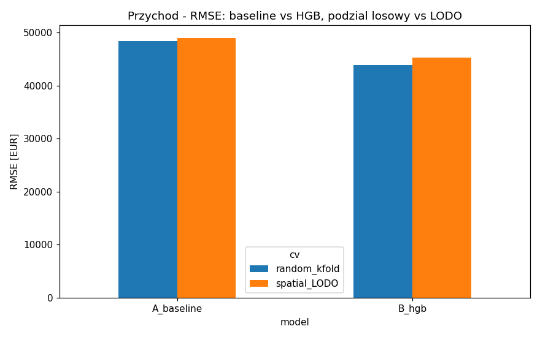

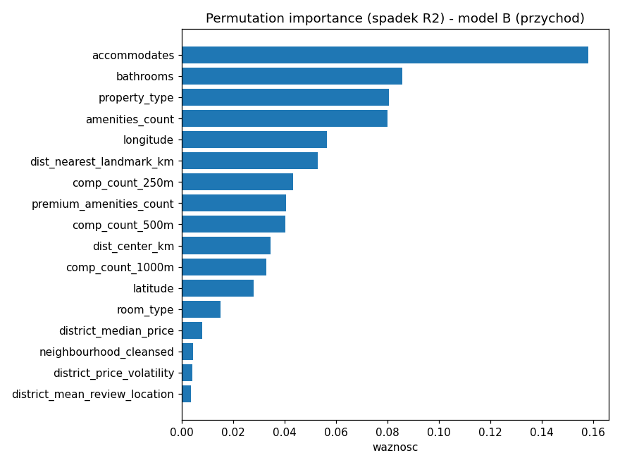

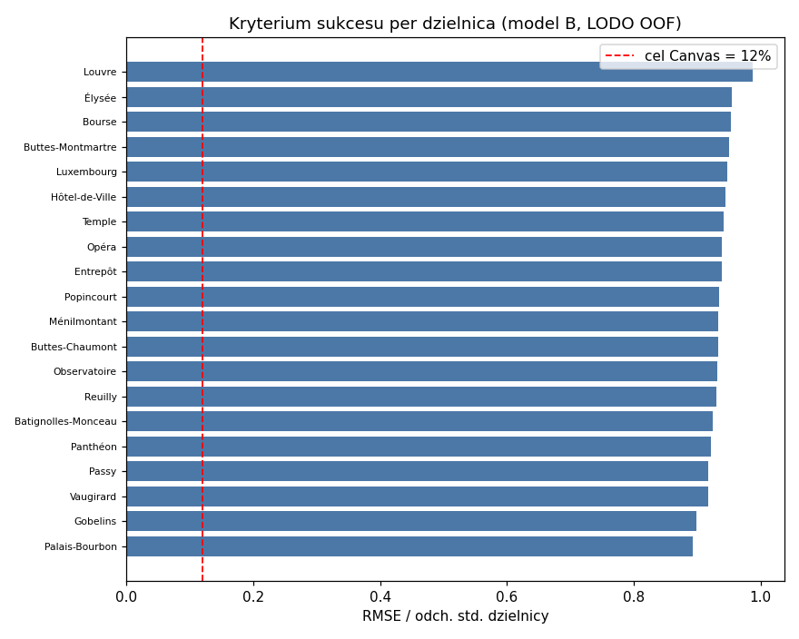

```python
from IPython.display import Image, display
display(Image(filename='figures/model_cv_comparison.png'))
display(Image(filename='figures/model_b_importance.png'))
display(Image(filename='figures/per_cluster_rmse_vs_std.png'))
```

## 6. Mapa potencjału i „białe plamy"

Na siatce nałożonej na Paryż liczymy dla profilu referencyjnego (cały lokal, 4 osoby) WPF (predykcja przychodu modelu B), przewidywane **obłożenie** (drugi model B) oraz saturację (liczba ofert w 500 m). **Biała plama** = wysoki WPF (≥70 pct) i niska saturacja (≤30 pct); przewidywane obłożenie wzbogaca listę Top‑N o sygnał popytu (jak szybko lokal się zapełni). Wynik: mapa ciepła + lista Top‑N dla Business Development — `figures/whitespot_map.png` (notatnik `02_modeling.ipynb`).

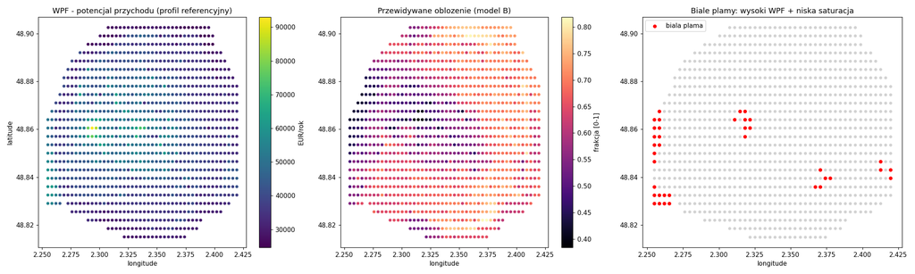

```python
from IPython.display import Image, display
display(Image(filename='figures/whitespot_map.png'))
```

## 7. Wdrożenie produkcyjne — mikroserwis + eksperyment A/B

Mikroserwis FastAPI (`src/nocarz/app.py`, port 8080):

- `POST /predict_revenue` — serwowanie predykcji; wybór modelu **przezroczysty** dla klienta (odpowiedź nie ujawnia, który model odpowiedział). Odpowiedź zwraca **oba** wyniki Canvas: `predicted_annual_revenue` i `predicted_occupancy`.
- `GET /health`, `POST /predict_revenue/{a|b}` (debug/wymuszenie — testy i analiza parowana).
- **Routing A/B:** deterministyczny hash (sha256) klucza (`client_id` lub `listing_id`), 50/50, „lepki" (ten sam klient → ten sam model), bez stanu. Rerandomizacja przez `SALT`, strojenie udziału przez `NOCARZ_AB_SPLIT`.
- **Logowanie:** każda predykcja → linia JSON (`logs/predictions.jsonl`, `schema_version=2`) z wersjami modeli (przychód + obłożenie), cechami, obiema predykcjami, latencją i miejscem na prawdę (uzupełniane offline). Rejestr modeli (`models/registry.json`, struktura rola→cel→wersja) umożliwia wdrażanie kolejnych wersji bez zmian w kodzie.

Predykcje serwowane są przez modele wytrenowane na **części treningowej** (80%), a eksperyment A/B ocenia je na **wydzielonym zbiorze testowym** (18 024 ofert nieużytych w treningu).

## 8. Wyniki eksperymentu A/B (z loga mikroserwisu)

Symulacja: `simulate_clients.py` odtworzył 800 ofert testowych (`scripts/evaluate_ab.py`).

**Przychód (główne KPI):**

| Model | n | RMSE | MAE | R² | mediana AE |
| --- | --- | --- | --- | --- | --- |
| A (bazowy) | 378 | 47 875 | 31 106 | 0.039 | 22 647 |
| B (HGB) | 422 | 42 937 | 25 156 | 0.181 | 16 964 |

- Mann‑Whitney U (błąd bezwzgl., niezależny): p = 9.8e‑5 — istotnie na korzyść B.
- **Test parowany** (te same oferty przez `/a` i `/b`, n=800): Wilcoxon p ≈ 1.8e‑15 — silnie na korzyść B (najmocniejszy test, eliminuje wpływ doboru ofert).
- Bootstrap 95% CI luki RMSE(A)−RMSE(B): [−8 274, 18 013] — **nieistotne** (RMSE zdominowane przez ciężki ogon błędów przy ~400 obserwacjach/grupę).

**Obłożenie (drugi wynik Canvas):**

| Model | n | RMSE | MAE | R² | mediana AE |
| --- | --- | --- | --- | --- | --- |
| A (bazowy) | 378 | 0.360 | 0.325 | 0.026 | 0.325 |
| B (HGB) | 422 | 0.354 | 0.309 | 0.059 | 0.309 |

Model B jest lepszy także dla obłożenia (niższe RMSE/MAE, wyższe R²). Wykresy obu celów + pełne testy: `reports/ab_report.md`.

**Werdykt:** wdrożyć **model B**. Przewaga jest istotna na MAE i w teście parowanym; brak istotności na RMSE wynika z ciężkiego ogona — zysk B dotyczy ofert typowych. Pełny raport: `reports/ab_report.md`.

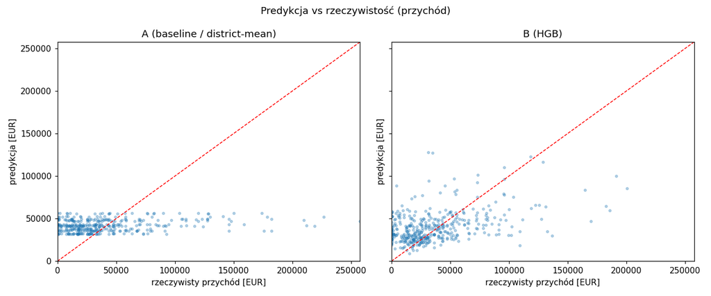

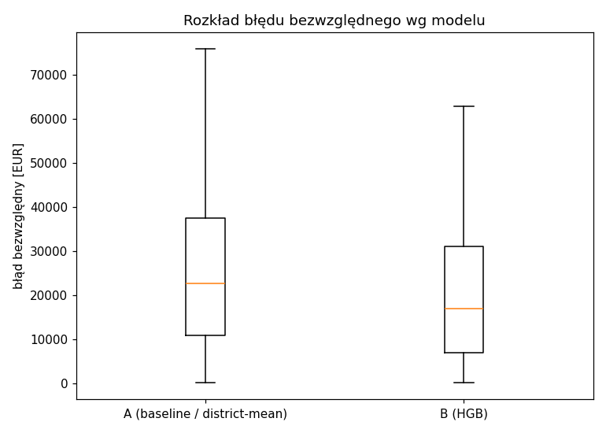

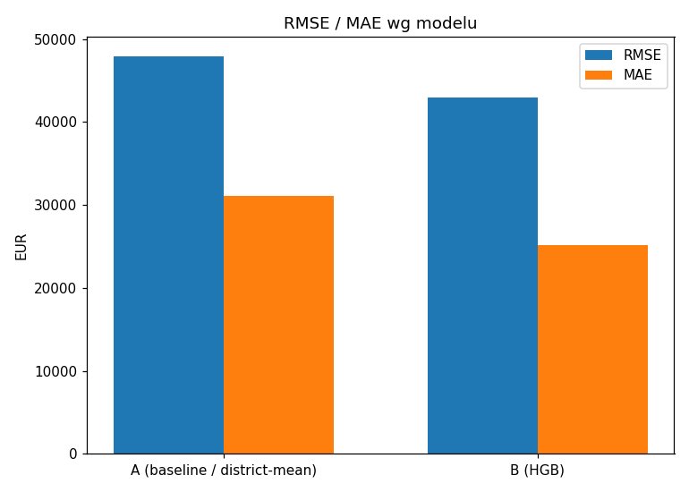

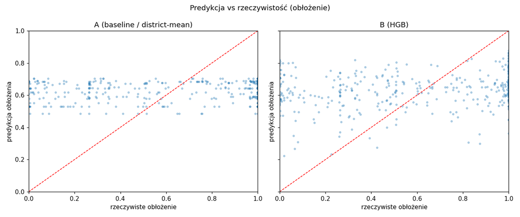

```python
from IPython.display import Image, display
display(Image(filename='figures/ab_pred_vs_actual.png'))
display(Image(filename='figures/ab_abs_error_box.png'))
display(Image(filename='figures/ab_metric_bars.png'))
display(Image(filename='figures/ab_occupancy_pred_vs_actual.png'))
```

## 9. Ograniczenia i dalsze kroki

- `available == False` łączy „zarezerwowane" i „zablokowane przez gospodarza".
- Bezwzględne R² jest niskie (celowe pominięcie własnej ceny) — model służy do **rankingu lokalizacji**, nie precyzyjnej wyceny. Dotyczy to obu celów (przychód i obłożenie).
- **Obłożenie (`occupancy`):** zrealizowane — drugi wynik Canvas jest modelowany (para A/B), serwowany (`predicted_occupancy`), oceniany w A/B i wykorzystany w mapie „białych plam". Jego moc predykcyjna jest skromna (LODO R²≈0.07), ale dodatnia i zgodna z kierunkiem przychodu.
- **`district_price_volatility`** to proxy przekrojowe — pełna „historyczna zmienność ceny" z Canvas wymagałaby szeregu czasowego (`calendar_prev.csv`), którego w danych brak.
- Dalej: cechy popytu z `sessions.csv`, sentyment z `reviews.csv` (NLP), pełne strojenie hiperparametrów, monitoring dryfu danych (zgodnie z Canvas). Transformacja log celu została **przetestowana i odrzucona** (§5).

## 10. Co to znaczy dla Business Development (interpretacja biznesowa)

Inwestora nie interesuje R² — interesuje go, **czy model pomaga wybierać lepsze lokalizacje niż dotychczasowa intuicja (dzielnica)**. Tak prezentujemy skuteczność:

- **Język pieniądza zamiast statystyki.** Model B myli się średnio o **~25 200 EUR** (MAE) na ofertę wobec **~31 100 EUR** dla podejścia „średnia dzielnicy" — **~19% mniej błędu**. Na typowej (medianowej) ofercie błąd to **~17 000 EUR** wobec ~22 600 EUR (**~25% mniej**). Każda trafniejsza decyzja to oszczędność kosztu pozyskania oferenta w nierentownej lokalizacji.
- **To jest decyzja rankingowa, nie wycena co do euro.** Cel z Canvas (RMSE < 12% odch. std.) zakłada precyzyjną wycenę kwotową — to jest nieosiągalne *przed* startem oferty bez znajomości jej własnej ceny (potwierdza to analiza per‑dzielnica w §5). Ale zadanie biznesowe brzmi „**gdzie** szukać", a do uszeregowania lokalizacji model B ma realną i istotną przewagę (parowany Wilcoxon p ≈ 1.8e‑15).
- **Dwa sygnały, jedna decyzja.** Obok przychodu dostarczamy przewidywane **obłożenie** — dział widzi nie tylko *ile* lokalizacja może zarobić, ale *jak szybko* się zapełni (płynność leadu).
- **Namacalny produkt.** Wynik dla działu to nie liczba, lecz **mapa potencjału + lista Top‑N „białych plam"** (wysoki przewidywany przychód, niska saturacja konkurencji — §6). To gotowy lead do działania, a nie metryka do interpretacji.
- **Jak zmierzyć sukces po wdrożeniu (zgodnie z Canvas):** eksperyment A/B na żywym ruchu mierzy **Revenue Lift** lokali pozyskanych z rekomendacji vs organicznych oraz współczynnik konwersji w strefach „białych plam" — wprost przekładalne na przychód serwisu z prowizji.

## 11. Jak uruchomić

Najwygodniej uruchomić projekt przez Docker — przygotowaliśmy jeden obraz działający w czterech trybach (`pipeline`, `serve`, `ab`, `test`); dokładne polecenia znajdują się w `README.md`.

Tryb `pipeline` przechodzi przez cały potok offline: wyznacza zmienną celu z kalendarza, buduje cechy, trenuje modele i przygotowuje zbiór ground truth. Tryb `serve` podnosi mikroserwis predykcji. Tryb `ab` przeprowadza pełny eksperyment A/B i zapisuje jego wyniki do `reports/ab_report.md`, a `test` uruchamia zestaw testów.